# Sweets Assignment

Allison Haywood, Amy Schroeder, Laetitia Piers

30 March 2016

# Hypothesis One

## Effect Size

Null Hypothesis: There is no significant difference in effect size between the types of sweets.

Alternative Hypothesis: There is a significant difference in effect size between the types of sweets.

```r
sweets <- read.csv(file = "sweets.csv", header = TRUE)

salty <- sweets[sweets$type == "salty",]
sour <- sweets[sweets$type == "sour",]
fizzer <- sweets[sweets$type == "fizzer",]

sweets$ES <- c((salty$time2 - salty$time1), (sour$time2 - sour$time1), (fizzer$time3 - fizzer$time1))

sweets$ES
```

```
##  [1]  35.00   9.00  -3.24  -8.40 -37.03 -29.00  -1.25  29.83  17.00  -3.00
## [11]   2.62  -2.28   3.09   2.08  -1.00   1.00  -2.00  -0.16  -4.90  12.00
## [21]  16.00 -78.85 -29.60     NA     NA  19.94  14.89  15.00   3.00  14.05
## [31]  -0.59   9.67   0.44  12.00  20.00  13.00   1.57  72.75
```

Imported data from notepad, into R. A dataframe “sweets” was created containing the sweet.csv data.

For each sweet type a dataframe was created.

A dataframe “sweets$ES” was created which contains the data which was calculated using the follwing formula: **Final Size - Initial Size = Effect Size**.

## Test for Normality

```r
assumptions <- function(x){
  var <- round(var(x, na.rm = T),2)
  nor <- round(shapiro.test(x)$p.value,2)
  result <- data.frame(var, nor)
  return(result)
}

assumptions(sweets$ES)
```

```
##      var nor
## 1 544.95   0
```

To test whether the data is parametric or nonparametric.

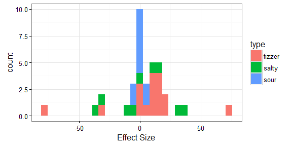

The effect sizes of the three different types of sweets.

## Comparison of the types of sweets

```r
summary(aov(ES~type, data = sweets))
```

```
##             Df Sum Sq Mean Sq F value Pr(>F)
## type         2    382   190.9   0.337  0.716
## Residuals   33  18691   566.4
## 2 observations deleted due to missingness
```

```r
TukeyHSD(aov(ES~type, data = sweets))
```

```
##   Tukey multiple comparisons of means
##     95% family-wise confidence level
##
## Fit: aov(formula = ES ~ type, data = sweets)
##
## $type
##                   diff       lwr      upr     p adj
## salty-fizzer -5.457255 -29.53103 18.61652 0.8440054
## sour-fizzer  -7.235588 -30.50903 16.03785 0.7280547
## sour-salty   -1.778333 -28.61069 25.05402 0.9855317
```

The ANOVA p value > 0.05 for all three comparisons, thus we do not Reject the Null Hypothesis. There is no significant difference in effect size between the types of sweets.

# Hypothesis Two

## Hypothesis

Null Hypothesis: There is no significant correlation in effect size between chew times for salty, sour and fizzer.

Alternative Hypothesis: There is a significant correlation in effect size between chew times for salty, sour and fizzer.

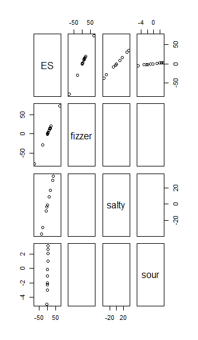

```r
library(reshape2)

sweetswide <- dcast(sweets[,c(3,7)], ES ~type,
                    value.var = "ES", mean, na.rm = TRUE)

pairs(sweetswide)
```

```r
cor(sweetswide[,c(2,3,4)])
```

```
##        fizzer salty sour
## fizzer      1    NA   NA
## salty      NA     1   NA
## sour       NA    NA    1
```

We changed the format to Wide because it is better to read since there are more rows than columns, and thus reduce the number of variables.

The table showing the correlation of the types of sweets are showing invalid data because all individuals did not complete all the tasks (chewing of sweets).

# Hypothesis Three

## Hypothesis

Null Hypothesis: There is no significant difference between consecutive chewing times or gender for the fizzer.

Alternative Hypothesis: There is a significant difference between consecutive chewing times or gender for the fizzer.

```r
sweetsSG <- sweets[20:38, c(1,4,5,6,7)]
sweetsSG
```

```
##    gender  time1  time2  time3     ES
## 20      F  77.00  93.00  89.00  12.00
## 21      F 102.00 123.00 118.00  16.00
## 22      M 171.85 120.75  93.00 -78.85
## 23      F 127.80 108.80  98.20 -29.60
## 24      F     NA     NA     NA     NA
## 25      F     NA     NA     NA     NA
## 26      M  91.04  83.73 110.98  19.94
## 27      M  94.94 117.84 109.83  14.89
## 28      F  80.00  86.00  95.00  15.00
## 29      M  65.00  59.00  68.00   3.00
## 30      F  59.25  56.46  73.30  14.05
## 31      F  73.85  50.85  73.26  -0.59
## 32      F 102.63 107.07 112.30   9.67
## 33      F  47.90  45.28  48.34   0.44
## 34      M  59.00  63.00  71.00  12.00
## 35      M  40.00  38.10  60.00  20.00
## 36      M  28.00  29.00  41.00  13.00
## 37      F  53.69  56.97  55.26   1.57
## 38      F  71.35  90.25 144.10  72.75
```

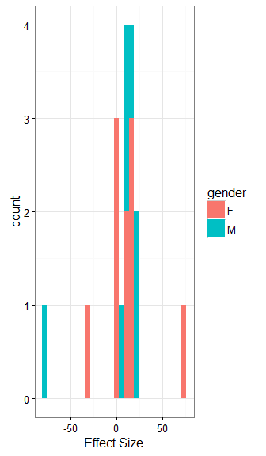

```r
library(ggplot2)
ggplot(data = sweetsSG, aes (x = ES),(group = gender)) +
  geom_histogram(aes(fill = gender)) +
  labs(x = "Effect Size") +
  theme_bw()
```

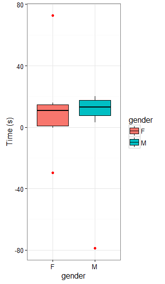

```r
ggplot(data = sweetsSG, aes(x = gender, y = ES)) +
  geom_boxplot(aes(fill = gender), outlier.colour = "red", colour = "black") +
  labs(y = "Time (s)") +
  theme_bw()
```

```r
Male <- sweetsSG[sweetsSG$gender == "M",]
Female <- sweetsSG[sweetsSG$gender == "F",]

t.test(Male$ES, Female$ES,
       paired = FALSE, alternative = "two.sided")
```

```
##
##  Welch Two Sample t-test
##
## data:  Male$ES and Female$ES
## t = -0.67481, df = 10.228, p-value = 0.5148
## alternative hypothesis: true difference in means is not equal to 0
## 95 percent confidence interval:
##  -45.32442  24.20356
## sample estimates:
##  mean of x  mean of y
##  0.5685714 11.1290000
```

We created a dataframe with only Male sweet times, similarly we created a dataframe containing only Female sweet times.

The t-Test p value > 0.05, thus we do not Reject the Null Hypothesis. There is no significant difference between consecutive chewing times or gender for the fizzer.

The t-Test statistical analysis was used because we are using gender, which is two datasets: Male and Female.

# Hypothesis Four

## Hypothesis

Null Hypothesis: There is no significant interaction between chewing times and gender for the fizzer.

Alternative Hypothesis: This is a significant interaction between chewing times and gender for the fizzer.

```r
summary(aov(ES~gender, data = sweetsSG))
```

```
##             Df Sum Sq Mean Sq F value Pr(>F)
## gender       1    459   459.2   0.514  0.484
## Residuals   15  13405   893.7
## 2 observations deleted due to missingness
```

```r
TukeyHSD(aov(ES~gender, data = sweetsSG))
```

```
##   Tukey multiple comparisons of means
##     95% family-wise confidence level
##
## Fit: aov(formula = ES ~ gender, data = sweetsSG)
##
## $gender
##          diff      lwr      upr     p adj
## M-F -10.56043 -41.9616 20.84074 0.4844973
```

The summary and TukeyHSD statistical analyses both shows a p value > 0.05, thus we do not Reject the Null Hypothesis. There is no significant interaction between chewing times and gender for the fizzer.